# Reproducible Research: Peer Assessment 1

Chunjin Feng

Monday, August 11, 2014

## Loading and preprocessing the data

```r
## import the data into R
activity<-read.csv("J:/Rwin/R/rr/activity.csv",header=TRUE)
head(activity)
```

```
##   steps       date interval
## 1    NA 2012-10-01        0
## 2    NA 2012-10-01        5
## 3    NA 2012-10-01       10
## 4    NA 2012-10-01       15
## 5    NA 2012-10-01       20
## 6    NA 2012-10-01       25
```

```r
## No need to process the data,for it is a clean dataset
```

## What is mean total number of steps taken per day?

#### 1. We make a histogram of the total number of steps taken each day

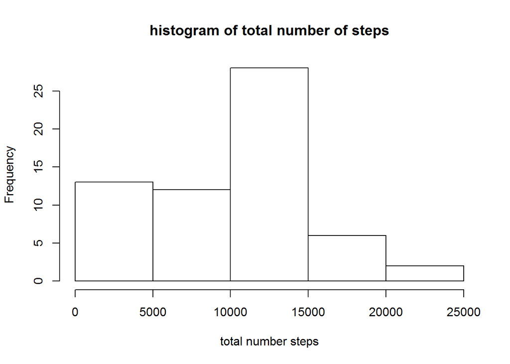

```r
totalstep<-tapply(activity$steps,activity$date,sum,na.rm=TRUE)
hist(totalstep,main="histogram of total number of steps",
     xlab="total number steps")
```

```r
## Calculate the mean
stepmean<-tapply(activity$steps,activity$date,mean,na.rm=TRUE)
stepmean
```

```
## 2012-10-01 2012-10-02 2012-10-03 2012-10-04 2012-10-05 2012-10-06
##        NaN     0.4375    39.4167    42.0694    46.1597    53.5417
## 2012-10-07 2012-10-08 2012-10-09 2012-10-10 2012-10-11 2012-10-12
##    38.2465        NaN    44.4826    34.3750    35.7778    60.3542
## 2012-10-13 2012-10-14 2012-10-15 2012-10-16 2012-10-17 2012-10-18
##    43.1458    52.4236    35.2049    52.3750    46.7083    34.9167
## 2012-10-19 2012-10-20 2012-10-21 2012-10-22 2012-10-23 2012-10-24
##    41.0729    36.0938    30.6285    46.7361    30.9653    29.0104
## 2012-10-25 2012-10-26 2012-10-27 2012-10-28 2012-10-29 2012-10-30
##     8.6528    23.5347    35.1354    39.7847    17.4236    34.0938
## 2012-10-31 2012-11-01 2012-11-02 2012-11-03 2012-11-04 2012-11-05
##    53.5208        NaN    36.8056    36.7049        NaN    36.2465
## 2012-11-06 2012-11-07 2012-11-08 2012-11-09 2012-11-10 2012-11-11
##    28.9375    44.7326    11.1771        NaN        NaN    43.7778
## 2012-11-12 2012-11-13 2012-11-14 2012-11-15 2012-11-16 2012-11-17
##    37.3785    25.4722        NaN     0.1424    18.8924    49.7882
## 2012-11-18 2012-11-19 2012-11-20 2012-11-21 2012-11-22 2012-11-23
##    52.4653    30.6979    15.5278    44.3993    70.9271    73.5903
## 2012-11-24 2012-11-25 2012-11-26 2012-11-27 2012-11-28 2012-11-29
##    50.2708    41.0903    38.7569    47.3819    35.3576    24.4688
## 2012-11-30
##        NaN
```

```r
## Calculate the median
stepmedian<-tapply(activity$steps,activity$date,median,na.rm=TRUE)
stepmedian
```

```
## 2012-10-01 2012-10-02 2012-10-03 2012-10-04 2012-10-05 2012-10-06
##         NA          0          0          0          0          0
## 2012-10-07 2012-10-08 2012-10-09 2012-10-10 2012-10-11 2012-10-12
##          0         NA          0          0          0          0
## 2012-10-13 2012-10-14 2012-10-15 2012-10-16 2012-10-17 2012-10-18
##          0          0          0          0          0          0
## 2012-10-19 2012-10-20 2012-10-21 2012-10-22 2012-10-23 2012-10-24
##          0          0          0          0          0          0
## 2012-10-25 2012-10-26 2012-10-27 2012-10-28 2012-10-29 2012-10-30
##          0          0          0          0          0          0
## 2012-10-31 2012-11-01 2012-11-02 2012-11-03 2012-11-04 2012-11-05
##          0         NA          0          0         NA          0
## 2012-11-06 2012-11-07 2012-11-08 2012-11-09 2012-11-10 2012-11-11
##          0          0          0         NA         NA          0
## 2012-11-12 2012-11-13 2012-11-14 2012-11-15 2012-11-16 2012-11-17
##          0          0         NA          0          0          0
## 2012-11-18 2012-11-19 2012-11-20 2012-11-21 2012-11-22 2012-11-23
##          0          0          0          0          0          0
## 2012-11-24 2012-11-25 2012-11-26 2012-11-27 2012-11-28 2012-11-29
##          0          0          0          0          0          0
## 2012-11-30
##         NA
```

## What is the average daily activity pattern?

#### 1.Make a time series plot of the 5-minute interval (x-axis) and the average number of steps taken, averaged across all days (y-axis)

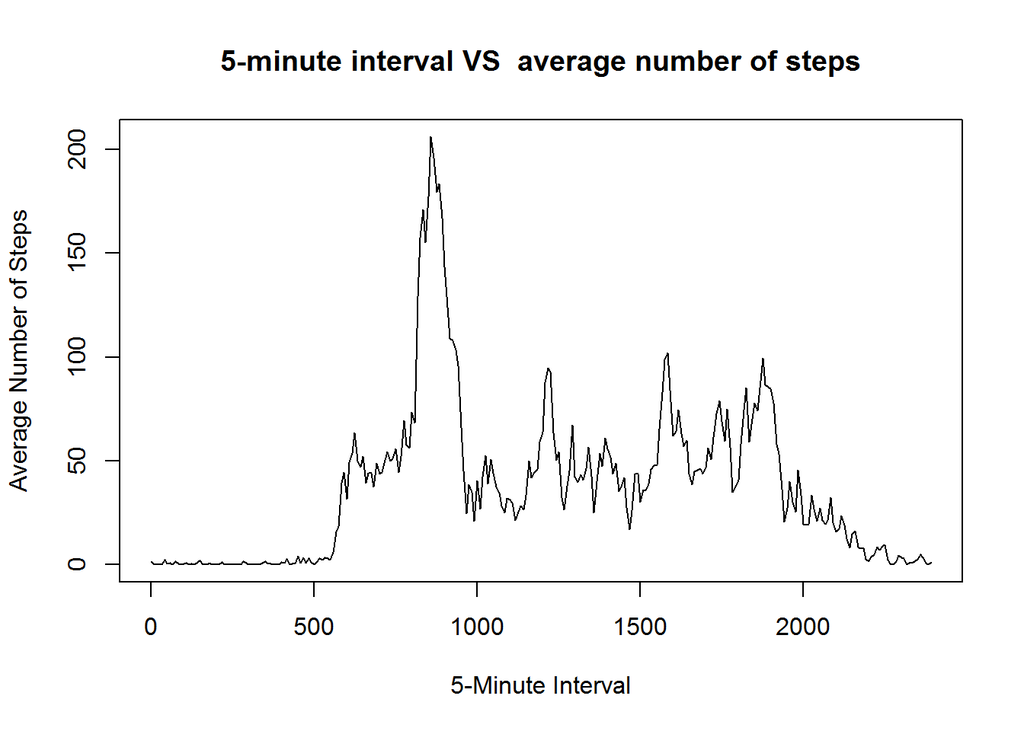

```r
intervalmean<- tapply(activity$steps,activity$interval,mean,na.rm=TRUE)
xlabname<- as.numeric(names(intervalmean))
plot(intervalmean, type="l",main="5-minute interval VS  average number of steps", xaxt="n", xlab="5-Minute Interval", ylab="Average Number of Steps")
axis(1,at=seq(1,288,60), labels=xlabname[seq(1,288,60)])
```

#### 2.Which 5-minute interval, on average across all the days in the dataset, contains the maximum number of steps?

You will know that the interval of 835 contains the maximum average number of steps.

```r
intervalmean[which.max(intervalmean)]
```

```
##   835
## 206.2
```

## Imputing missing values

Note that there are a number of days/intervals where there are missing values (coded as NA). The presence of missing days may introduce bias into some calculations or summaries of the data.

#### 1.Calculate and report the total number of missing values in the dataset

```r
sum(is.na(activity))
```

```
## [1] 2304
```

```r
## for how many rows have the missing value,we can use na.omit command
nrow(activity)-nrow(na.omit(activity))
```

```
## [1] 2304
```

We find that these two numbers are the same.

##### 2.Devise a strategy for filling in all of the missing values in the dataset.

```
we use the mean for that 5-minute interval to input the missing value,for if we use the mean for that day ,but that day contains all missing values,in this way,we cannot input the missing values.Since the 5-minute interval value does not miss too many ,we can take this measure.
```

#### 3.Create a new dataset that is equal to the original dataset but with the missing data filled in.

```r
## We construct a new column to indicate row number of the missing value
activity$number<-1:nrow(activity)
## we abstract the missing value rows
zz<-activity[is.na(activity$steps),-1]
## contruct a new dataframe of 5-minute interval mean
intervaldf<-data.frame(interval=xlabname,steps=intervalmean)
## imputing the missing values
fullvalue<-merge(zz,intervaldf,by="interval",all=TRUE)
##check the missing values
sum(is.na(fullvalue))
```

```
## [1] 0
```

```r
## Imputing the missing values into the original dataset
activity$steps[fullvalue$number]<- fullvalue$steps
## delete the column of indicating the missing values numbers
activity2<-activity[,-4]
##Create a new dataset that is equal to the original dataset but with the missing data filled in.
write.csv(activity2,"activity2.csv",row.names=F)
```

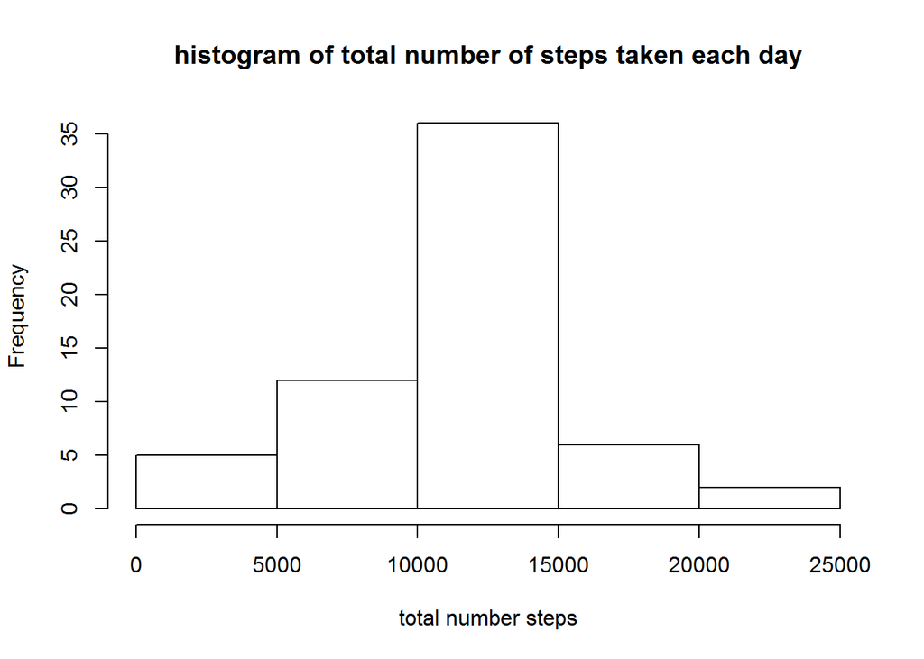

```r
totalstep2<-tapply(activity2$steps,activity2$date,sum)
hist(totalstep2,main="histogram of total number of steps taken each day",xlab="total number steps")
```

```r
## calculate the new mean
stepmean2<-tapply(activity2$steps,activity2$date,mean)
stepmean2
```

```
## 2012-10-01 2012-10-02 2012-10-03 2012-10-04 2012-10-05 2012-10-06
##    37.3826     0.4375    39.4167    42.0694    46.1597    53.5417
## 2012-10-07 2012-10-08 2012-10-09 2012-10-10 2012-10-11 2012-10-12
##    38.2465    37.3826    44.4826    34.3750    35.7778    60.3542
## 2012-10-13 2012-10-14 2012-10-15 2012-10-16 2012-10-17 2012-10-18
##    43.1458    52.4236    35.2049    52.3750    46.7083    34.9167
## 2012-10-19 2012-10-20 2012-10-21 2012-10-22 2012-10-23 2012-10-24
##    41.0729    36.0938    30.6285    46.7361    30.9653    29.0104
## 2012-10-25 2012-10-26 2012-10-27 2012-10-28 2012-10-29 2012-10-30
##     8.6528    23.5347    35.1354    39.7847    17.4236    34.0938
## 2012-10-31 2012-11-01 2012-11-02 2012-11-03 2012-11-04 2012-11-05
##    53.5208    37.3826    36.8056    36.7049    37.3826    36.2465
## 2012-11-06 2012-11-07 2012-11-08 2012-11-09 2012-11-10 2012-11-11
##    28.9375    44.7326    11.1771    37.3826    37.3826    43.7778
## 2012-11-12 2012-11-13 2012-11-14 2012-11-15 2012-11-16 2012-11-17
##    37.3785    25.4722    37.3826     0.1424    18.8924    49.7882
## 2012-11-18 2012-11-19 2012-11-20 2012-11-21 2012-11-22 2012-11-23
##    52.4653    30.6979    15.5278    44.3993    70.9271    73.5903
## 2012-11-24 2012-11-25 2012-11-26 2012-11-27 2012-11-28 2012-11-29
##    50.2708    41.0903    38.7569    47.3819    35.3576    24.4688
## 2012-11-30
##    37.3826
```

```r
## calculate the new median
stepmedian2<-tapply(activity2$steps,activity2$date,median)
stepmedian2
```

```
## 2012-10-01 2012-10-02 2012-10-03 2012-10-04 2012-10-05 2012-10-06
##      34.11       0.00       0.00       0.00       0.00       0.00
## 2012-10-07 2012-10-08 2012-10-09 2012-10-10 2012-10-11 2012-10-12
##       0.00      34.11       0.00       0.00       0.00       0.00
## 2012-10-13 2012-10-14 2012-10-15 2012-10-16 2012-10-17 2012-10-18
##       0.00       0.00       0.00       0.00       0.00       0.00
## 2012-10-19 2012-10-20 2012-10-21 2012-10-22 2012-10-23 2012-10-24
##       0.00       0.00       0.00       0.00       0.00       0.00
## 2012-10-25 2012-10-26 2012-10-27 2012-10-28 2012-10-29 2012-10-30
##       0.00       0.00       0.00       0.00       0.00       0.00
## 2012-10-31 2012-11-01 2012-11-02 2012-11-03 2012-11-04 2012-11-05
##       0.00      34.11       0.00       0.00      34.11       0.00
## 2012-11-06 2012-11-07 2012-11-08 2012-11-09 2012-11-10 2012-11-11
##       0.00       0.00       0.00      34.11      34.11       0.00
## 2012-11-12 2012-11-13 2012-11-14 2012-11-15 2012-11-16 2012-11-17
##       0.00       0.00      34.11       0.00       0.00       0.00
## 2012-11-18 2012-11-19 2012-11-20 2012-11-21 2012-11-22 2012-11-23
##       0.00       0.00       0.00       0.00       0.00       0.00
## 2012-11-24 2012-11-25 2012-11-26 2012-11-27 2012-11-28 2012-11-29
##       0.00       0.00       0.00       0.00       0.00       0.00
## 2012-11-30
##      34.11
```

```
From above,we can see the new mean and median are different from the mean and median of missing values.And the histogram drew can also shows that the data are inclined into normal distribution.
```

Imputing missing data do have an influence on the distribution of the data.

## Are there differences in activity patterns between weekdays and weekends?

```r
## to draw the plot ,we will use lattice package
library(lattice)
Sys.setlocale("LC_TIME", "C")
```

```
## [1] "C"
```

```r
ttt<-strptime(activity2$date,"%Y-%m-%d")
## use the weekdays function ,changing the date into weekdays
day<-weekdays(ttt)
## change "Sunday" and"weekday" into "weekend"
day[day %in% c("Sunday","Saturday")]<-"weekend"
## the rest of them will be "weekday""
day[day !="weekend"]<-"weekday"
## change the day variable into factor in order to split
activity2$day<-as.factor(day)
## split the activity2,get a list of two dataframe,one is "weekday"",the other is "weekend""
day.split<-split(activity2,activity2$day)
## calculate each interval's mean value
meanstep1<-tapply(day.split[[1]]$steps,day.split[[1]]$interval,mean)
meanstep2<-tapply(day.split[[2]]$steps,day.split[[2]]$interval,mean)
## contruct a new dataframe for plotting
final.week<-data.frame(meanstep=c(meanstep1,meanstep2),
        interval=rep(rownames(meanstep2),2),
        day=rep(c("weekday","weekend"),each=length(meanstep2)),
        stringsAsFactors =FALSE)
```

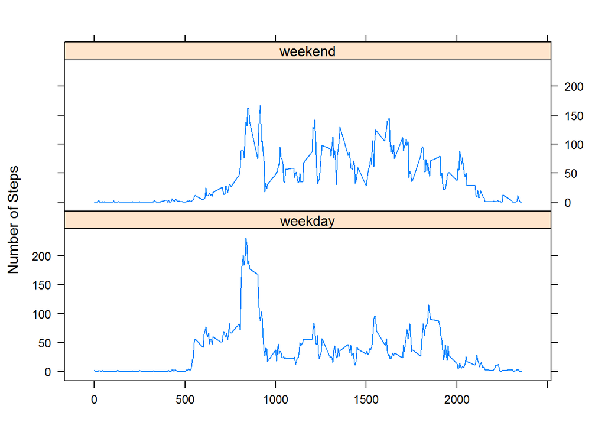

```r
xyplot(meanstep~as.numeric(interval)|factor(day),type="a",data=final.week,layout=c(1,2), xlab="",ylab="Number of Steps")
```

```r
mean(meanstep1)
```

```
## [1] 35.61
```

```r
mean(meanstep2)
```

```
## [1] 42.37
```

From the above picture,we can know the maximun value of the steps was in weekdays not at weekend.But the average of steps at weekend (42.3664) is higher than the average of steps in weekdays (35.6106).During some specific intervals,weekdays shows higher values than weekend ,such as during interval of 500 to 700.

So indeed,there are differences in activity patterns between weekdays and weekends.